# Taux d’emploi et taux d’activité. Résultats détaillés de l’Enquête Emploi de l’Insee

@statjunior

mai 28, 2023

# 1 Présentation

Ce rapport **Rmarkdwon** synthétise les résultats de l’Enquête Emploi sur les grands indicateurs du marché du travail. Le pas des graphiques est trimestriel. Le dernier point connu est le 1er trimestre 2023.

Le rapport détaille les taux d’emploi ainsi que les taux d’activité par genre et par tranche d’âge.

Les taux d’emploi sont différenciés en fonction de la durée du contrat de travail (temps complet, temps partiel, et synthèse du taux d’emploi en équivalent temps plein).

La contribution des CDD et de l’intérim, ainsi que du sous-emploi est aussi présentée.

Enfin, le rapport présente le nombre d’heures moyen hebdomadaire par emploi.

Les graphiques peuvent être interprétés de manière structurelle (évolutions sur longue période du taux d’emploi des femmes ou des seniors par exemple), ou bien de manière conjoncturelle (variations d’un indicateur d’un trimestre à l’autre).

[output not shown]

# 2 Taux d’activité au sens du BIT

Le taux d’activité au sens du BIT rapporte l’ensemble des personnes en emploi ou au chômage (au sens du BIT) par rapport à l’ensemble de la population. Pour les graphiques d’ensemble, la population retenue est celle en âge de travailler au sens du BIT, c’est à dire de 15 à 64 ans.

## 2.1 Taux d’activité par âge

[figure not shown]

## 2.2 Taux d’activité par sexe

[figure not shown]

# 3 Taux d’emploi au sens du BIT

## 3.1 Taux d’emploi par âge

[figure not shown]

## 3.2 Taux d’emploi par sexe

[figure not shown]

# 4 Taux d’emploi par catégorie

## 4.1 Temps de travail

### 4.1.1 Taux d’emploi à temps complet par âge

[figure not shown]

### 4.1.2 Taux d’emploi à temps complet par sexe

[figure not shown]

## 4.2 Taux d’emploi à temps partiel

### 4.2.1 Taux d’emploi à temps partiel par âge

[figure not shown]

### 4.2.2 Taux d’emploi à temps partiel par sexe

[figure not shown]

## 4.3 Taux d’emploi en Equivalent Temps Plein (EQTP)

### 4.3.1 Taux d’emploi en EQTP par âge

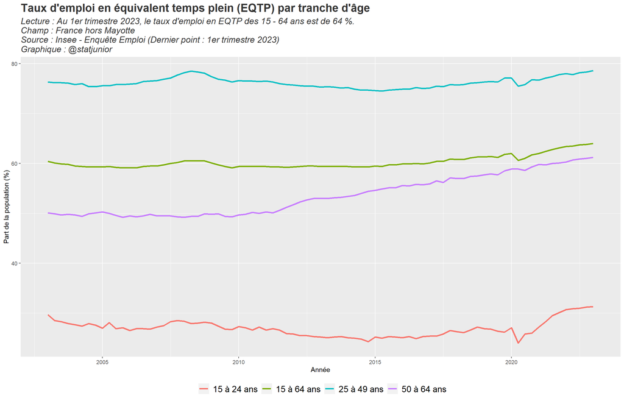

### 4.3.2 Taux d’emploi en EQTP par sexe

[figure not shown]

## 4.4 Contribution du Sous-emploi au taux d’emploi total

[figure not shown]

## 4.5 Taux d’emploi en CDD ou en intérim

[figure not shown]

## 4.6 Nombre moyen d’heures travaillées hebdomadaire

[figure not shown]